Final Project Report

**ALY6000 Introduction to Analytics**  
**NORTHEASTERN UNIVERSITY**  
DEVIKA PATIL  
MAJOR-PROJECT MANAGEMENT  
DATE OF SUBMISSION: 18-02-2023

Dr.Dee Chiluiza, PhD

**ACKNOWLEDGEMENT**

I would like to express my deepest gratitude to my supervisor,Dr.Dee Chiluiza, for their guidance, encouragement, and insightful feedback throughout the project. Their valuable suggestions and support have helped me in completing this project successfully.

I would also like to thank Sadaf Fathima, Vedant Wagh, and Sujay Torvi for their valuable assistance in the data collection and analysis process. Their contributions have helped me to understand the project better and have improved the overall quality of the project.

In addition, I would like to express my appreciation to the Northeastern University for providing the necessary resources and support to carry out this project. Without their support, this project would not have been possible.

Finally, I would like to acknowledge my family and friends for their unwavering support and encouragement throughout this project. Their motivation and love have kept me going, and I am forever grateful for their presence in my life.

**INTRODUCTION**

One of the most important measures used by companies to monitor their performance and expansion is sales data. In the current global economy, businesses are relying more and more on data analytics to improve their sales tactics and boost income. Businesses may now manage sales data from different sources, including website traffic, social media, and mobile apps, thanks to the growth of e-commerce and online marketplaces. This enables companies to understand consumer behavior and preferences, spot trends, and make informed decisions. Businesses can also spot market trends and modify their marketing plans by examining sales data. Businesses can examine vast volumes of sales data with the use of powerful data analytics tools to acquire a competitive advantage and achieve sustainable growth in the global market.(Africapolis,2021)

The dataset likely includes information about different departments, their respective total sales, and the market area in which the sales took place. This type of data could be used to analyze sales performance, identify areas of growth, and make data-driven business decisions. It may also be used for predictive modeling to forecast future sales trends.

Analyzing sales data,measuring customer satisfaction,evaluating product quality,monitoring financial performance.In summary, descriptive statistics plays a critical role in helping businesses to analyze and interpret data related to sales, customer satisfaction, product quality, and financial performance. By using descriptive statistics, businesses can make informed decisions and take actions to improve their operations, products, and services.

An R script is a plain text file that contains a series of commands in the R programming language. The script can be run in R to perform a series of analyses on data. The script can also be saved and re-used later.

Pros: R scripts are very simple to create and can be used to automate repetitive tasks. R scripts are easy to read and modify, making them useful for collaborative work. R scripts can be used to create reproducible code, which is important for scientific research.

Cons: R scripts don’t include any text formatting or document structure. It is hard to include explanations of the analysis performed in R scripts.

R Markdown is a document format that combines R code, text, and formatting in a single file. R Markdown files can be converted to different formats such as PDF, HTML or Word documents. The code blocks within an R Markdown document can be executed and the results can be displayed directly in the document.

Pros: R Markdown files provide the ability to integrate text, code, and output, making it easy to create documents with explanatory text and figures. R Markdown files can be easily exported into different formats for sharing with others. R Markdown files are a great tool for reproducible research and data analysis.

Cons: R Markdown can be complex and time-consuming to learn. R Markdown can be difficult to debug if there is a problem with the formatting.

```r
#task1-descriptive statistics for the database

Stat_min = prod_Data %>% select(Product_Price, Quantity, Shipping_Cost_Each, Returns, Loss_Per_Return)%>%
  summarise_all(min)
Stat_max  = prod_Data %>% select(Product_Price, Quantity, Shipping_Cost_Each, Returns, Loss_Per_Return)%>%
  summarise_all(max)
Stat_sd = prod_Data %>% select(Product_Price, Quantity, Shipping_Cost_Each, Returns, Loss_Per_Return)%>%
 summarise_all(sd)
Stat_var  = prod_Data %>% select(Product_Price, Quantity, Shipping_Cost_Each, Returns, Loss_Per_Return)%>%
 summarise_all(var)
Stat_mean = prod_Data %>% select(Product_Price, Quantity, Shipping_Cost_Each, Returns, Loss_Per_Return)%>%
  summarise_all(mean)
Stat_median  = prod_Data %>% select(Product_Price, Quantity, Shipping_Cost_Each, Returns, Loss_Per_Return)%>%
  summarise_all(median)
```

```r
##create table with columns and rows
B1_tab = matrix(c(round(Stat_mean,2),round(Stat_median,2),round(Stat_min,2),round(Stat_max,2),
                  round(Stat_sd,2),round(Stat_var,2)),byrow = TRUE, nrow = 6)
col_names = c("Product_price","Quantity","Shipping_cost","Returns","Loss_per_return")
r_names = c("mean","median","minimum","maximum","sd","variance")
colnames(B1_tab) = col_names
rownames(B1_tab) = r_names
knitr::kable(B1_tab, digits = 2,
             caption = "Table :Total sales per department",
             format = "html",
             table.attr = "style='width:40%:'",
             align = 'c')%>%
  kable_classic(bootstrap_options = "basic",
                full_width = TRUE,
                position = "center",
                font_size = 12)
```

|  | Product_price | Quantity | Shipping_cost | Returns | Loss_per_return |
| --- | --- | --- | --- | --- | --- |
| mean | 548.9 | 158.52 | 14.32 | 47.59 | 168.92 |
| median | 501.35 | 133 | 8.59 | 40 | 145.66 |
| minimum | 151.93 | 20 | 0 | 6 | 18.23 |
| maximum | 3558.41 | 400 | 59.71 | 120 | 1352.2 |
| sd | 293.96 | 116.09 | 13.98 | 34.83 | 122.83 |
| variance | 86412.8 | 13475.82 | 195.4 | 1212.87 | 15088.21 |

```r
#observations:the statistics include mean,median,minimum value, maximum value, standard deviation, variance of product_price,quantity,shipping_cost, returns,loss_per_return.
```

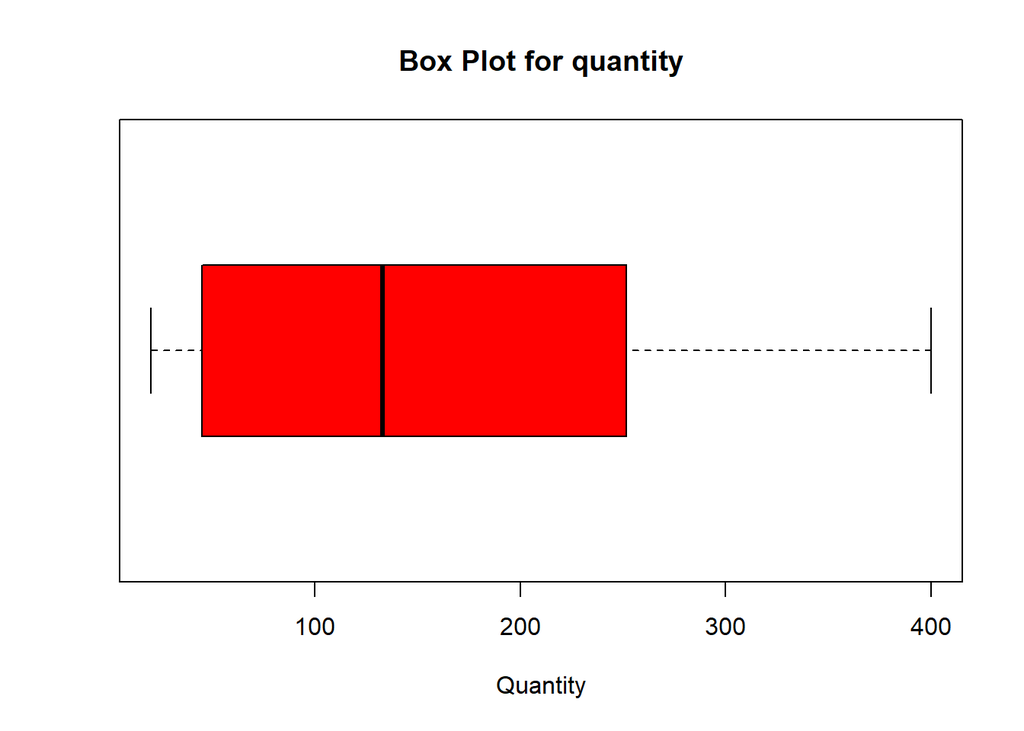

```r
##create a boxplot graph
boxplot(prod_Data$Quantity, horizontal = T, xlab ="Quantity", main ="Box Plot for quantity", col="red")
```

```r
#Observations:median is positioned between 100 to 200 with no potential outliers.
```

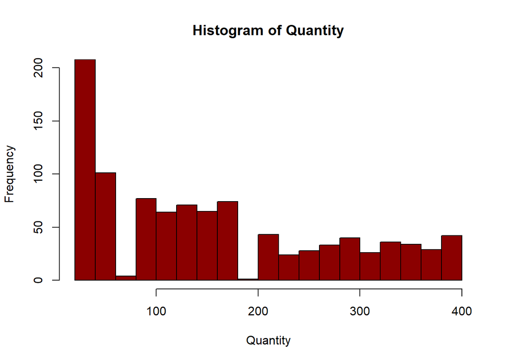

```r
##task 1(continued):
hist(prod_Data$Quantity, main="Histogram of Quantity", xlab="Quantity", breaks = 25, ylim=c(0,200), col="darkred")
```

```r
#observations:the quantity peaks around 0-100 and then decreases as graph proceeds further.
```

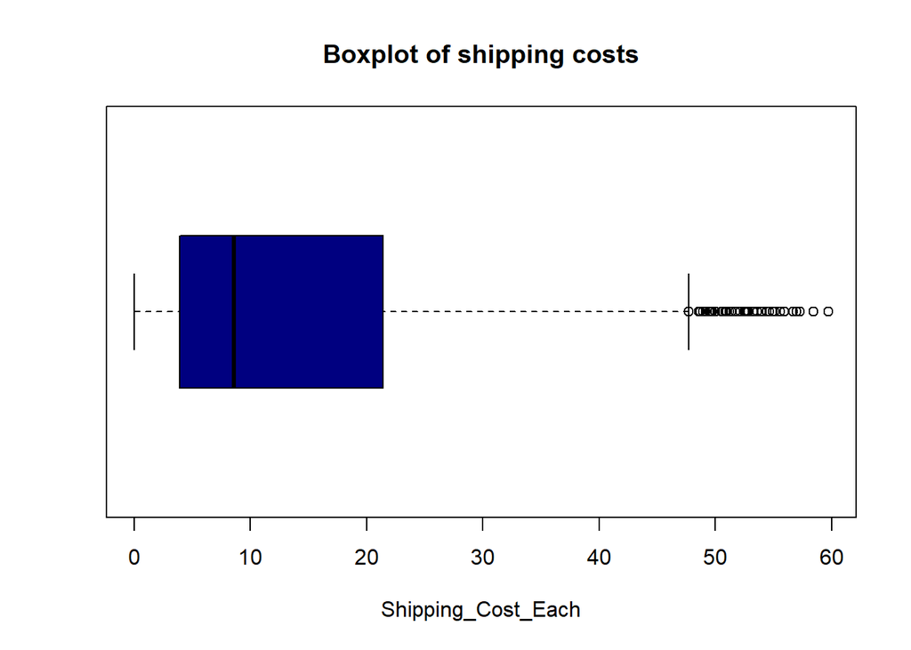

```r
#create boxplot
boxplot(prod_Data$Shipping_Cost_Each, main ="Boxplot of shipping costs", xlab="Shipping_Cost_Each", horizontal = TRUE, col = "navyblue")
```

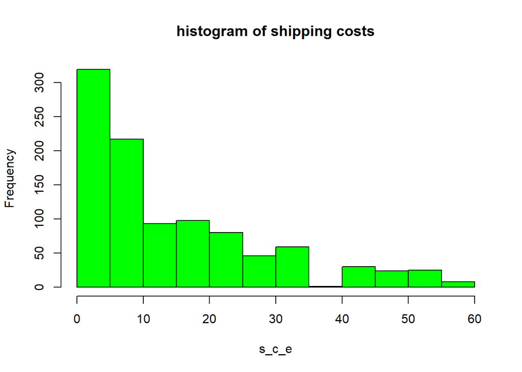

```r
#create histogram
hist(prod_Data$Shipping_Cost_Each, main = "histogram of shipping costs", xlab = "s_c_e", breaks = 20, col = "green")
```

```r
#observations: From the boxplot the median shipping cost lies between the range of 0-10 and the potential outliers starting from being between 40-50 and contnuing thereafter and from the histogram we see that the frequency peaks between 0-10 and gradually decreases as we proceed further.
```